# Tarea 4: 11/09/2017

## Tarea 4: 10/09/2017

*Jorge Altamirano*

```r
library(readr)
library(tidyr)
library(dplyr)
library(tabplot)
library(ROCR)
library(ggplot2)
set.seed(175904)
```

```r
columns2keep = c("cfsc", "cfpar", "cfbrack", "cfexc",
                 "cfdollar", "cfpound", "spam")
spam_entrena <- read_csv('spam-entrena.csv')
spam_prueba <- read_csv('spam-prueba.csv')
spam_entrena <- spam_entrena[, names(spam_entrena) %in% columns2keep]
spam_prueba <- spam_prueba[, names(spam_prueba) %in% columns2keep]
rm(columns2keep)
spam_entrena$spam <- as.factor(spam_entrena$spam)
spam_prueba$spam <- as.factor(spam_prueba$spam)
```

```r
table(spam_entrena$spam)
```

```
   0    1
1861 1206
```

```r
glimpse(spam_entrena)
```

```
Observations: 3,067
Variables: 7
$ cfsc     <dbl> 0.000, 0.000, 0.000, 0.000, 0.000, 0.000, 0.000, 0.165, 0.000, 0.015...
$ cfpar    <dbl> 0.000, 0.065, 0.000, 0.133, 0.000, 0.000, 0.205, 0.182, 0.000, 0.030...
$ cfbrack  <dbl> 0.000, 0.000, 0.000, 0.066, 0.000, 0.000, 0.000, 0.091, 0.000, 0.000...
$ cfexc    <dbl> 0.107, 0.461, 0.000, 0.468, 0.715, 0.833, 0.153, 0.000, 0.000, 0.000...
$ cfdollar <dbl> 0.000, 0.527, 0.000, 0.267, 0.318, 0.000, 0.128, 0.016, 0.000, 0.046...
$ cfpound  <dbl> 0.000, 0.000, 0.000, 0.000, 0.000, 0.416, 0.102, 0.000, 0.000, 0.000...
$ spam     <fctr> 1, 1, 0, 1, 1, 0, 1, 0, 0, 0, 0, 0, 1, 1, 1, 0, 0, 1, 0, 0, 1, 1, 0...
```

```r
summary(spam_entrena)
```

```
      cfsc             cfpar           cfbrack            cfexc            cfdollar
 Min.   :0.00000   Min.   :0.0000   Min.   :0.00000   Min.   : 0.0000   Min.   :0.0000
 1st Qu.:0.00000   1st Qu.:0.0000   1st Qu.:0.00000   1st Qu.: 0.0000   1st Qu.:0.0000
 Median :0.00000   Median :0.0650   Median :0.00000   Median : 0.0000   Median :0.0000
 Mean   :0.04052   Mean   :0.1395   Mean   :0.01795   Mean   : 0.2662   Mean   :0.0743
 3rd Qu.:0.00000   3rd Qu.:0.1885   3rd Qu.:0.00000   3rd Qu.: 0.3010   3rd Qu.:0.0500
 Max.   :4.36700   Max.   :9.7520   Max.   :4.08100   Max.   :32.4780   Max.   :6.0030
    cfpound         spam
 Min.   : 0.00000   0:1861
 1st Qu.: 0.00000   1:1206
 Median : 0.00000
 Mean   : 0.03848
 3rd Qu.: 0.00000
 Max.   :13.12900
```

```r
mod1 <- glm(spam ~ cfsc + cfpar + cfbrack + cfexc + cfdollar + cfpound,
            spam_entrena,
            family = "binomial")
```

```
glm.fit: fitted probabilities numerically 0 or 1 occurred
```

```r
summary(mod1)
```

```
Call:
glm(formula = spam ~ cfsc + cfpar + cfbrack + cfexc + cfdollar +
    cfpound, family = "binomial", data = spam_entrena)

Deviance Residuals:
    Min       1Q   Median       3Q      Max
-8.4904  -0.7270  -0.5603   0.6012   2.5107

Coefficients:
            Estimate Std. Error z value Pr(>|z|)
(Intercept) -1.19573    0.06619 -18.066  < 2e-16 ***
cfsc        -1.11752    0.52647  -2.123   0.0338 *
cfpar       -1.65865    0.30171  -5.497 3.85e-08 ***
cfbrack     -2.02263    1.03569  -1.953   0.0508 .
cfexc        1.63224    0.13929  11.719  < 2e-16 ***
cfdollar    14.87256    0.84558  17.589  < 2e-16 ***
cfpound      0.65780    0.27429   2.398   0.0165 *
---
Signif. codes:  0 ‘***’ 0.001 ‘**’ 0.01 ‘*’ 0.05 ‘.’ 0.1 ‘ ’ 1

(Dispersion parameter for binomial family taken to be 1)

    Null deviance: 4110.8  on 3066  degrees of freedom
Residual deviance: 2829.9  on 3060  degrees of freedom
AIC: 2843.9

Number of Fisher Scoring iterations: 7
```

## Con las variables CF… (Frecuencia de caracter)

### Curva Entrenamiento con Variables de CF (Frecuencia de Caracter)

```r
spam_entrena$probs_test1 <- predict(mod1, newdata = spam_entrena, type = 'response')
summary(spam_entrena$probs_test1)
```

```
     Min.   1st Qu.    Median      Mean   3rd Qu.      Max.
0.0000734 0.2005587 0.2322363 0.3932181 0.5785090 1.0000000
```

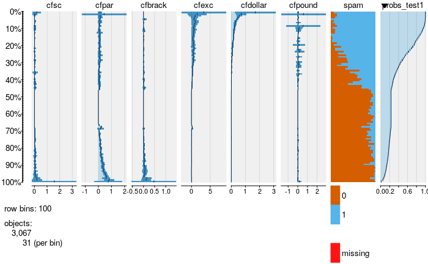

```r
tableplot(spam_entrena, sortCol = probs_test1, scale = "lin" )
```

```r
tolerance = 0.24
table(spam_entrena$probs_test1 > tolerance, spam_entrena$spam)
```

```
           0    1
  FALSE 1510  171
  TRUE   351 1035
```

```r
prop.table(table(spam_entrena$probs_test1 > tolerance, spam_entrena$spam), 2)
```

```
                0         1
  FALSE 0.8113917 0.1417910
  TRUE  0.1886083 0.8582090
```

### Curva Prueba con Variables de CF (Frecuencia de Caracter)

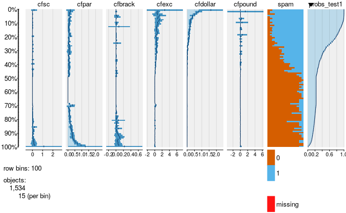

```r
spam_prueba$probs_test1 <- predict(mod1, newdata = spam_prueba,
                                      type = "response")
tableplot(spam_prueba, sortCol = probs_test1, scales = "lin")
```

```r
tolerance = 0.27
table(spam_prueba$probs_test1 > tolerance, spam_prueba$spam)
```

```
          0   1
  FALSE 749 106
  TRUE  178 501
```

```r
prop.table(table(spam_prueba$probs_test1 > tolerance, spam_prueba$spam), 2)
```

```
                0         1
  FALSE 0.8079827 0.1746293
  TRUE  0.1920173 0.8253707
```

## Prueba con modelo Quasipoisson *“Identidad”* con Variables de CF (Frecuencia de Caracter)

```r
mod2 <- glm(as.integer(spam) ~ cfsc + cfpar + cfbrack + cfexc + cfdollar + cfpound,
            spam_entrena, family = "quasipoisson")
```

### Curva Entrenamiento Quasipoisson *“Identidad”* con Variables de CF (Frecuencia de Caracter)

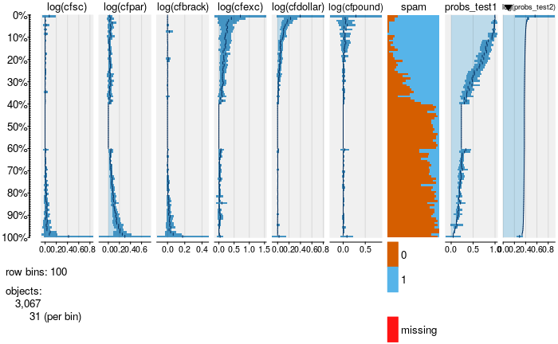

```r
spam_entrena$probs_test2 <- predict(mod2, newdata = spam_entrena,
                                      type = "response")
tableplot(spam_entrena,
          sortCol = probs_test2)
```

```r
tolerance = 0.24
table(spam_entrena$probs_test1 > tolerance, spam_entrena$spam)
```

```
           0    1
  FALSE 1510  171
  TRUE   351 1035
```

```r
prop.table(table(spam_entrena$probs_test1 > tolerance, spam_entrena$spam), 2)
```

```
                0         1
  FALSE 0.8113917 0.1417910
  TRUE  0.1886083 0.8582090
```

### Curva Prueba Quasipoisson *“Identidad”* con Variables de CF (Frecuencia de Caracter)

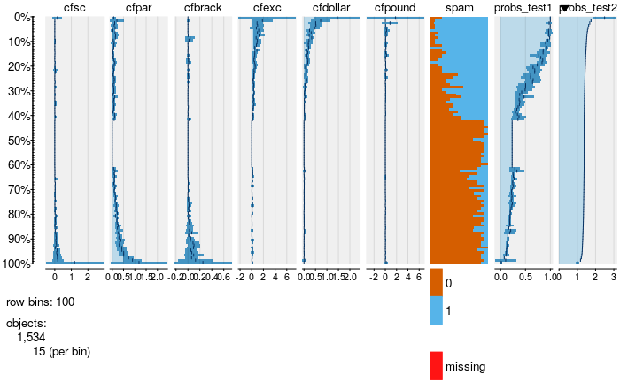

```r
spam_prueba$probs_test2 <- predict(mod2, newdata = spam_prueba,
  type = "response")
tableplot(spam_prueba, sortCol = probs_test2, scale = "lin")
```

```r
tolerance = 0.24
table(spam_entrena$probs_test1 > tolerance, spam_entrena$spam)
```

```
           0    1
  FALSE 1510  171
  TRUE   351 1035
```

```r
prop.table(table(spam_entrena$probs_test1 > tolerance, spam_entrena$spam), 2)
```

```
                0         1
  FALSE 0.8113917 0.1417910
  TRUE  0.1886083 0.8582090
```

## Con todas las variables

```r
spam_entrena <- read_csv('spam-entrena.csv')
spam_prueba <- read_csv('spam-prueba.csv')
spam_entrena$spam <- as.factor(spam_entrena$spam)
spam_prueba$spam <- as.factor(spam_prueba$spam)
```

```r
mod3 <- glm(spam ~ ., spam_entrena, family = "binomial")
```

```
glm.fit: fitted probabilities numerically 0 or 1 occurred
```

```r
mod4 <- glm(as.integer(spam) ~ ., spam_entrena, family = "quasipoisson")
```

### Coeficientes con todas las variables

```r
coef(mod3)[c(-1,-2)]
```

```
       wfmake     wfaddress         wfall          wf3d         wfour        wfover
-4.702374e-01 -1.579107e-01  3.000686e-01  2.399545e+00  5.472043e-01  6.503639e-01
     wfremove    wfinternet       wforder        wfmail     wfreceive        wfwill
 2.357017e+00  4.087402e-01  7.278708e-01  7.987863e-02  5.708188e-02 -1.365698e-01
     wfpeople      wfreport   wfaddresses        wffree    wfbusiness       wfemail
-7.341665e-03  1.046229e-01  1.056411e+00  1.040516e+00  9.442028e-01  1.535407e-01
        wfyou      wfcredit        wfyour        wffont         wf000       wfmoney
 9.202240e-02  8.241849e-01  2.058618e-01  2.134756e-01  2.592811e+00  3.044752e-01
         wfhp         wfhpl      wfgeorge         wf650         wflab        wflabs
-1.603236e+00 -1.153468e+00 -7.736858e+00  3.960473e-01 -2.863092e+00 -6.206288e-01
     wftelnet         wf857        wfdata         wf415          wf85  wftechnology
-1.424367e-01  1.900285e+00 -6.032621e-01 -7.082416e+00 -1.783782e+00  7.472379e-01
       wf1999       wfparts          wfpm      wfdirect          wfcs     wfmeeting
 3.531264e-01  7.806378e-01 -1.107835e+00 -1.847213e-01 -2.592203e+02 -2.833516e+00
   wforiginal     wfproject          wfre         wfedu       wftable  wfconference
-1.561105e+00 -1.905207e+00 -7.576755e-01 -1.199163e+00 -2.695776e+00 -3.968677e+00
         cfsc         cfpar       cfbrack         cfexc      cfdollar       cfpound
-1.447573e+00 -7.899047e-01 -6.663278e-01  3.149344e-01  6.171975e+00  2.951053e+00
   crlaverage    crllongest      crltotal
-8.438706e-03  8.201378e-03  9.676536e-04
```

### Curva Entrenamiento con Todas las Variables

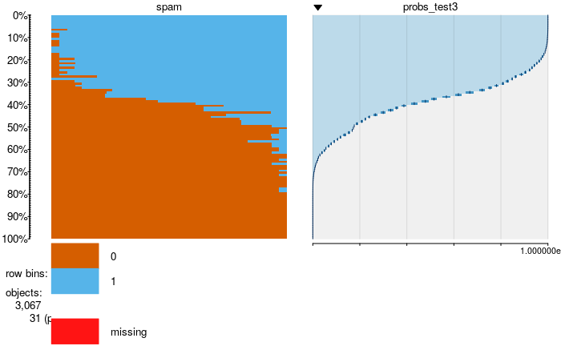

```r
spam_entrena$probs_test3 <- predict(mod3, newdata = spam_entrena,
  type = "response")
tableplot(spam_entrena[, 59:60], sortCol = probs_test3)
```

### Curva Prueba con Todas las Variables

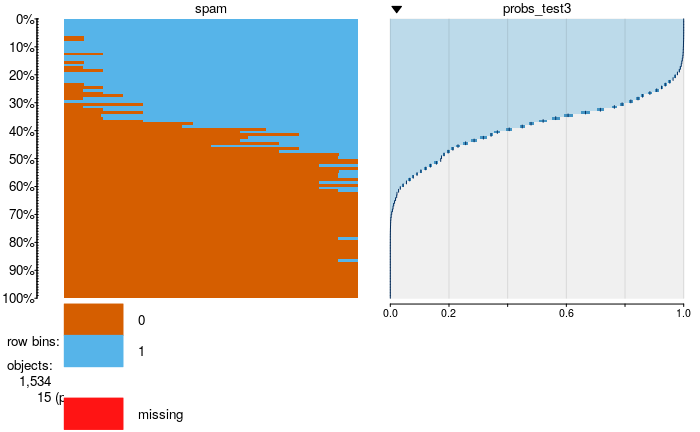

```r
spam_prueba$probs_test3 <- predict(mod3, newdata = spam_prueba, type = "response")
tableplot(spam_prueba[, 59:60], sortCol = probs_test3)
```

### Curva Entrenamiento Quasipoisson *“Identidad”* con Todas las Variables

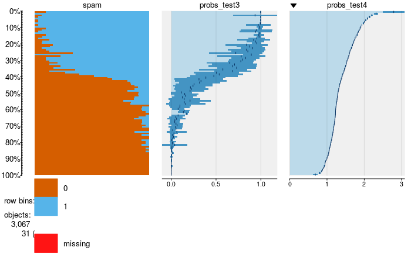

```r
spam_entrena$probs_test4 <- predict(mod4, newdata = spam_entrena,
  type = "response")
tableplot(spam_entrena[, 59:61], sortCol = probs_test4)
```

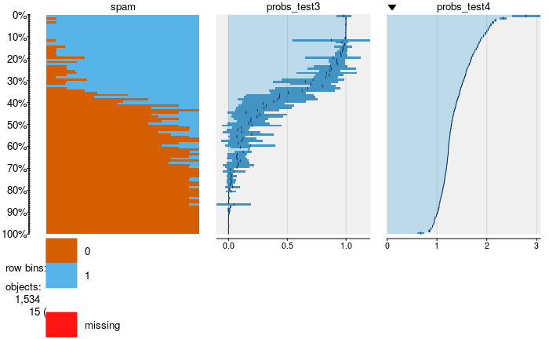

```r
spam_prueba$probs_test4 <- predict(mod4, newdata = spam_prueba,
  type = "response")
tableplot(spam_prueba[, 59:61], sortCol = probs_test4)
```

## Matrices de confusión y ROC

### Alta especificidad

```r
tolerance = 0.85
especificidad = table(spam_prueba$probs_test3 > tolerance, spam_prueba$spam)
especificidad
```

```
          0   1
  FALSE 910 191
  TRUE   17 416
```

```r
prop.table(especificidad)
```

```
                 0          1
  FALSE 0.59322034 0.12451108
  TRUE  0.01108214 0.27118644
```

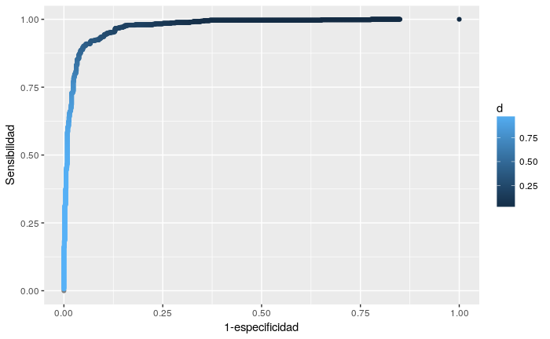

```r
roc_pred3 <- prediction(spam_prueba$probs_test3, spam_prueba$spam)
perf <- performance(roc_pred3, measure = "sens", x.measure = "fpr")
roc3 <- data_frame(tfp = perf@x.values[[1]], sens = perf@y.values[[1]],
                       d = perf@alpha.values[[1]])
ggplot(roc3, aes(x = tfp, y = sens, colour=d)) + geom_point() +
  xlab('1-especificidad') + ylab('Sensibilidad')
```

### Alta sensibilidad

```r
tolerance = 5e-2
especificidad = table(spam_prueba$probs_test3 > tolerance, spam_prueba$spam)
especificidad
```

```
          0   1
  FALSE 624   5
  TRUE  303 602
```

```r
prop.table(especificidad)
```

```
                  0           1
  FALSE 0.406779661 0.003259452
  TRUE  0.197522816 0.392438070
```

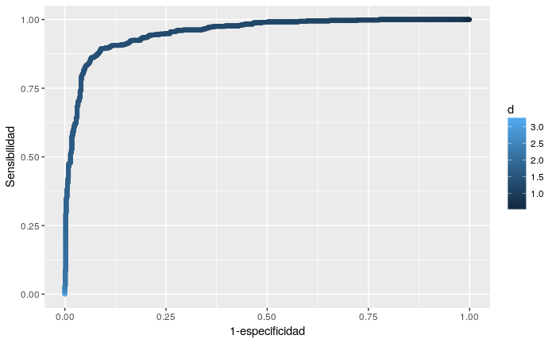

```r
roc_pred4 <- prediction(spam_prueba$probs_test4, spam_prueba$spam)
perf <- performance(roc_pred4, measure = "sens", x.measure = "fpr")
roc4 <- data_frame(tfp = perf@x.values[[1]], sens = perf@y.values[[1]],
                       d = perf@alpha.values[[1]])
ggplot(roc4, aes(x = tfp, y = sens, colour=d)) + geom_point() +
  xlab('1-especificidad') + ylab('Sensibilidad')
```

### ¿Qué es mejor: tener muchos falsos positivos o falsos negativos?

En mi experiencia es mejor tener un buen balance de falsos positivos con falsos negativos, debido a que ambos extremos causan problemas a Usuarios Finales (áreas fuera de TI). Aquí cito algunos ejemplos:

- Se generan muchos *tickets de soporte* y molestia por la falta de *accuracy* pues requieren que se liberen correos en la lista de SPAM por falsos positivos.
- Se genera aún mayor inconveniente y **pérdida de información** cuando se reciben correos con ligas a malware, donde existe pérdida de datos (como es el caso del *ransomware*: secuestro de información); lo cual se presenta en los falsos negativos
- El tener muchos falsos negativos causan que los spammers muchas veces puedan validar cuentas de correo, lo cual crea un círculo vicioso donde la gente que abre algunos correos falsos negativos recibe aún más spam.
- Es más difícil recibir retroalimentación de usuarios de falsos negativos en muchos casos, pues no generan reportes, y los dejan pasar por alto.